# W1_Exercise Solutions

Let’s take the previous plot and color each point by Sex, to see any correlations between Sex, Age and Fare:

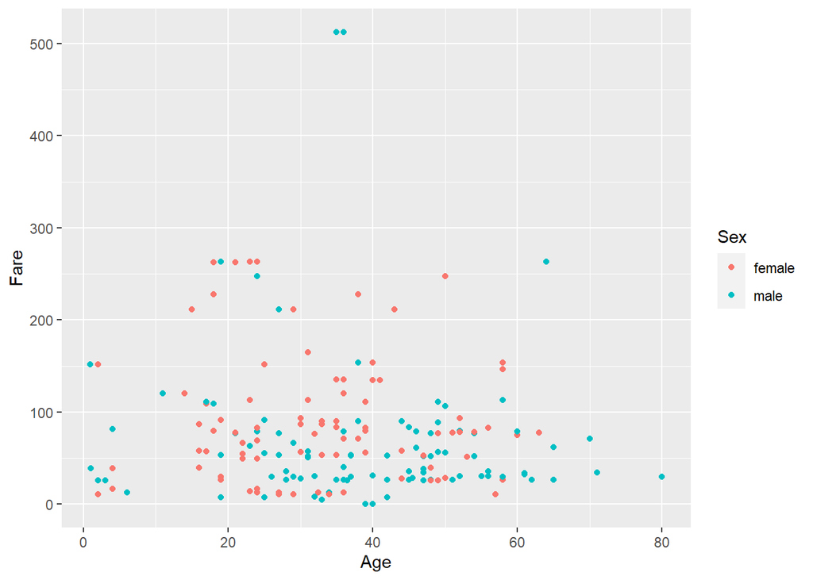

```r
# Scatter plot of Age vs Fare colored by Sex
ggplot(passengers1 %>% drop_na(), aes(x = Age, y = Fare, color = Sex)) +
  geom_point()
```

**What can you see here?**

Visualizing three variables on one plot is pretty cool, but what if wanted to throw the Survived variable into the mix to see if there are any apparent trends?

Faceting is a way to produce multiple plots simultaneously:

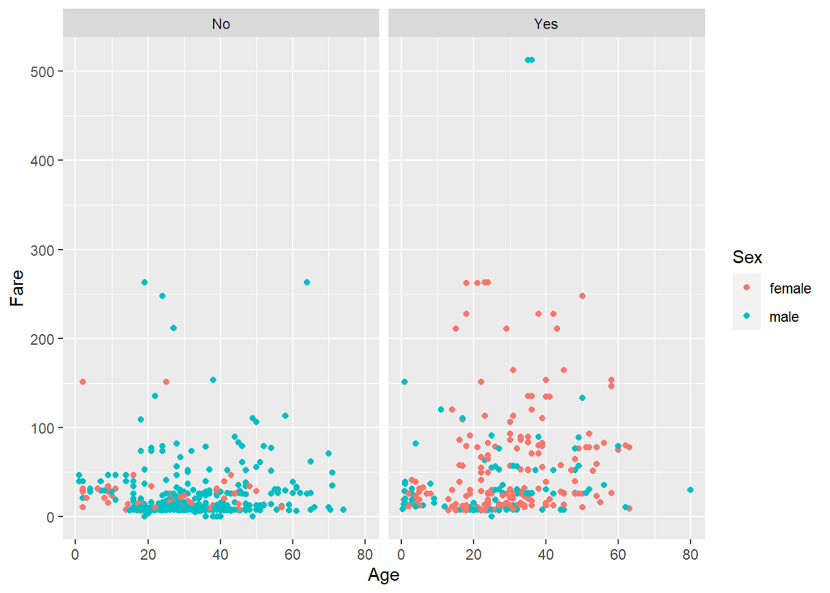

```r
# Scatter plot of Age vs Fare colored by Sex faceted by Survived
ggplot(passengers1, aes(x = Age, y = Fare, color = Sex)) +
  geom_point() +
  facet_grid(~Survived)
```

**What can you see here?**

Now let’s redo our bar plot of passenger “Sex” and this time fill our bars according to “Survived”:

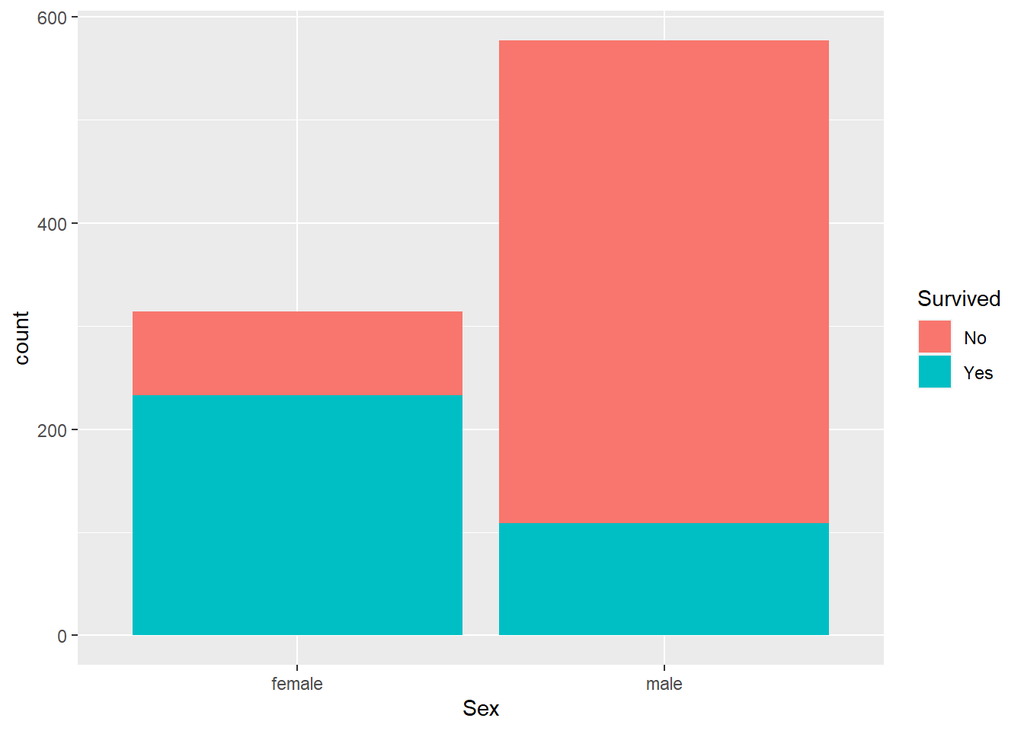

```r
# Plot barplot of passenger Sex & fill according to Survival
ggplot(passengers1, aes(x = Sex, fill = Survived)) +
  geom_bar()
```

**What can you see here?**

**Recap:**

- You’ve imported your data & checked it out
- You’ve learnt about the pipe operator `%>%`
- You can now use `dplyr` to wrangle your data: `filter` it, `arrange` it and create new features by `mutating` old ones.
- You’ve learnt how to easily and intuitively plot your data using `ggplot2`.

This was a first introduction to `ggplot2`, but we will be returning to data visualizations often. Reference the `ggplot2` [cheatsheet](https://www.rstudio.com/resources/cheatsheets/), or the [many examples](http://r-statistics.co/Top50-Ggplot2-Visualizations-MasterList-R-Code.html) for more details.

**Up next:**

- Learn how to summarise your data across many dimensions, such as “Sex”.

## Summarizing and grouping your data

Use the `summarise` verb to find out the mean fare paid:

```r
# Check out mean Fare
passengers %>%
  summarise(meanFare = mean(Fare))
```

```
## # A tibble: 1 × 1
##   meanFare
##      <dbl>
## 1     32.2
```

Use the `summarise` verb to find out the median fare paid:

```r
# Check out mean Fare
passengers %>%
  summarise(medianFare = median(Fare))
```

```
## # A tibble: 1 × 1
##   medianFare
##        <dbl>
## 1       14.5
```

**Note:** The British (`summarise()`) and American (`summarize()`) english spelling of the verb are interchangeable.

Use the `filter` and `summarise` verbs to find out the mean fare paid among men:

```r
# Check out mean Fare for men
passengers %>%
  filter(Sex == "male") %>%
  summarise(meanFare = mean(Fare))
```

```
## # A tibble: 1 × 1
##   meanFare
##      <dbl>
## 1     25.5
```

Use the `filter` and `summarise` verbs to find out the mean fare paid among women:

```r
# Check out mean Fare for women
passengers %>%
  filter(Sex == "female") %>%
  summarise(meanFare = mean(Fare))
```

```
## # A tibble: 1 × 1
##   meanFare
##      <dbl>
## 1     44.5
```

Use the `filter` and `summarise` verbs to find out the mean fare paid among women **and** how many women survived:

```r
# Check out mean Fare & number of survivors for women
passengers %>%
  filter(Sex == "female") %>%
  summarise(meanFare = mean(Fare), numSurv = sum(Survived))
```

```
## # A tibble: 1 × 2
##   meanFare numSurv
##      <dbl>   <dbl>
## 1     44.5     233
```

Use the `group_by` and `summarise` verbs to find the mean fare and number of survivors as a function of sex:

```r
# Check out mean Fare & number of survivors grouped by Sex
passengers %>%
  group_by(Sex) %>%
  summarise(meanFare = mean(Fare), numSurv = sum(Survived))
```

```
## # A tibble: 2 × 3
##   Sex    meanFare numSurv
##   <chr>     <dbl>   <dbl>
## 1 female     44.5     233
## 2 male       25.5     109
```

Use the `group_by` and `summarise` verbs to find the mean fare and proportion of survivors as a function of sex:

```r
# Check out mean Fare & proportion of survivors grouped by Sex
passengers %>%
  group_by(Sex) %>%
  summarise(meanFare = mean(Fare), numSurv = sum(Survived)/n())
```

```
## # A tibble: 2 × 3
##   Sex    meanFare numSurv
##   <chr>     <dbl>   <dbl>
## 1 female     44.5   0.742
## 2 male       25.5   0.189
```

**Recap:**

- You’ve imported your data & checked it out
- You’ve learnt about the pipe operator `%>%`
- You can now use `dplyr` to wrangle your data: `filter` it, `arrange` it and create new features by `mutating` old ones.
- You’ve learnt how to easily and intuitively plot your data using `ggplot2`.
- You’ve learnt how to summarise your data across many dimensions, such as “Sex”.

**Up next:**

- Break!
- Troubleshooting errors (lecture)

## Exploring further

We will now use some of the skills we’ve just learnt to answer a our own questions!

As a group:

1. Develop a question that can be answered with the `passengers1` dataset. See [dataset description](https://www.kaggle.com/c/titanic/data) for more details on each of the columns.
2. Talk through how the data needs to be manipulated to get the appropriate answer. Would plotting the data be useful? Which verbs will you use and in what order?
3. Write the code for the analysis. Designate a computer that will have the completed code. If you are not actively typing, you can help your group by thinking about what should come next or proof reading what has already been typed. Be sure to test your code often.

```r
#write your analysis here
```

4. When you are finished:
- save the file with your group number (ie. `W1_Group1.Rmd`)
- Knit the `.Rmd` (short for RMarkdown) to HTML using the Knit button. Open the HTML, what does it look like? We will explore this more during the next workshop.
- email the `.Rmd` to your group members and the instructor.